# Topic 9

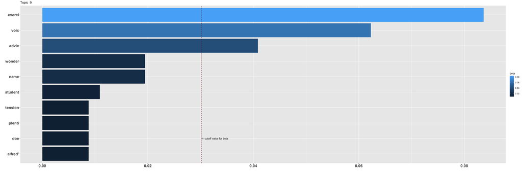

On interpreting beta: the term has a beta probability of being generated from the particular topic.

Values below are gamma : An estimated proportion of words from that document that are generated from that topic.

**Text Record Number: 238** gamma: 10 % likelihood of this document (based on its words) in this topic

**I think it’s worth forgetting how they’re written and just focus on what’s written.

The problem is that every passage in music can have a demand for different aproaches. When you’re approaching 4 parts, I’d suggest get the fingering in that’s comfortable. Bear in mind you can change it but once you find fingering that works, ALWAYS use it.

Then start learning each voice individually. Play each line on it’s own using the fingering you’re written in.

Then start piecing together 2 voices at a time. Soprano with bass, soprano with alto, soprano with tenor, alto with tenor, alto with bass and tenor with bass.

Understand each voice entirely then piece 3 voices together. Try singing the 4th voice with the other 3.

There’s a lot of work involved but you will fuly understand the piece and th structure and you can start to create your own interpretation.**

**Text Record Number: 1254** gamma: 10 % likelihood of this document (based on its words) in this topic

**Hello, I’ve recently decided to learn some fugues having gone through grades many years ago.

I’m having trouble trying to pick fingering, especially because, at least in my edition, the voices are basically written as bottom two in bass clef, top two in treble (for a 4 voice fugue, in particular BWV 846), but often I need left hand for top parts or vice versa. It’s really confusing too because the stems of the voices, even on a chord, point in opposite directions.

Does anyone have any advice on coming up with fingerings that work?**

**Text Record Number: 1181** gamma: 10 % likelihood of this document (based on its words) in this topic

**I know musictheory.net has lessons which can show you the very basics of note-reading, along with normal exercises which can be very helpful.

Other than that there are plenty of books in pdf form online you could scrounge up which show the basics. Also Youtube videos can be really helpful.

It’s worth it to get lessons if you can at any time, though, if they are serious about learning. Self-teaching is difficult.**

**Text Record Number: 1188** gamma: 10 % likelihood of this document (based on its words) in this topic

**I found finger exercises to be extremely useful in that sense. Liszt’s Technical Exercises are the most complete you can find around, but they are *a lot*, and unless you have 4 hours/day to dedicate to them (like Liszt used to do) you’ll probably be overwhelmed.

Dohnanyi’s Finger Exercises are essentially a summarised version of Liszt’s, and much more digestible. I’m using them regularly and my technique has definitely improved since I started practicing some of them regularly.**

**Text Record Number: 1072** gamma: 10 % likelihood of this document (based on its words) in this topic

**I read the Amazon preview. Sounds intriguing, I’ll look into it, thnx. Is this your work?**

**Text Record Number: 13** gamma: 10 % likelihood of this document (based on its words) in this topic

**Add a second voice, then add that E note as a whole note in the new voice. Then delete the note (changing it to a rest) in the original voice.**

**Text Record Number: 1282** gamma: 10 % likelihood of this document (based on its words) in this topic

**I’ve been playing piano for years and it’s been frustrating where I’m at with it. Let me lay out the details

- I can memorize and play very complicated pieces
- my sight reading is pretty damn slow
- I understand music theory pretty well
- implementing music theory is also too slow for playing along
- lessons are always either boringly easy, or extremely complex and no in between

I don’t really know where to go from here because all my exercises fall into the same trap as the pieces I learn; they just become memorized and I feel like I don’t derive anything from them. I’d like to be able to be faster at thinking around where I want to go on the piano without sounding boring and predictable. When I play a piece I know I get lauded, but the second I play with someone or try to improvise it’s like I’m a newborn calf.

Any ideas on how to bridge the gaps I have? Any exercises that have really helped y’all when in a long rut? Even a couple piano teachers have had trouble with it**